# Math 275 Lab 1

Spencer Tibbitts

September 26, 2019

The first step is to import the DataFrame from the url address below.

To view the names of DataFrame variables, we run the following command:

```r
names(cdc)
```

```
## [1] "genhlth"  "exerany"  "hlthplan" "smoke100" "height"   "weight"
## [7] "wtdesire" "age"      "gender"
```

### 1.

##### How many cases are there in this data set?

```r
length(names(cdc))
```

```
## [1] 9
```

##### For each variable, identify its data type (e.g. categorical, discrete).

- genhlth -> categorical (ordinal)
- exernany -> categorical (T/F)
- hlthplan -> categorical (T/F)
- smoke100 -> categorical (T/F)
- height -> numerical (discrete)
- weight -> numerical (discrete)
- wtdesire -> numerical (discrete)
- age -> numerical (discrete)
- gender -> categorical (nominal)

We can use the ‘head’ and ‘tail’ commands to view a small portion of the DataFrame at one glance.

```r
head(cdc)
```

```
##     genhlth exerany hlthplan smoke100 height weight wtdesire age gender
## 1      good       0        1        0     70    175      175  77      m
## 2      good       0        1        1     64    125      115  33      f
## 3      good       1        1        1     60    105      105  49      f
## 4      good       1        1        0     66    132      124  42      f
## 5 very good       0        1        0     61    150      130  55      f
## 6 very good       1        1        0     64    114      114  55      f
```

```r
tail(cdc)
```

```
##         genhlth exerany hlthplan smoke100 height weight wtdesire age
## 19995      good       0        1        1     69    224      224  73
## 19996      good       1        1        0     66    215      140  23
## 19997 excellent       0        1        0     73    200      185  35
## 19998      poor       0        1        0     65    216      150  57
## 19999      good       1        1        0     67    165      165  81
## 20000      good       1        1        1     69    170      165  83
##       gender
## 19995      m
## 19996      f
## 19997      m
## 19998      f
## 19999      f
## 20000      m
```

### 2. Create a numerical summary for height and age, and compute the IQR for each.

##### * Compute the relative frequency distribution for gender and exerany.

##### * How many males are in the sample?

##### * What proportion of the sample reports being in excellent health?

```r
height_sum <- summary(cdc$height)
height_IQR <- height_sum[4]-height_sum[2]

# Do the same for age
age_sum <- summary(cdc$age)
age_IQR <- age_sum[4] - age_sum[2]

height_IQR
```

```
##   Mean
## 3.1829
```

```r
age_IQR
```

```
##     Mean
## 14.06825
```

In order to find the number of males in the sample, we must generate the relative frequency distribution for gender.

```r
gender <- table(cdc$gender)
gender[1] # Number of Males (1=Female,0=Male)
```

```
##    m
## 9569
```

```r
# Relative Frequency Distribution of Exerany
exerany <- table(cdc$exerany)
exerany[2]/20000 # Percentage in Good Health (1 indicates good health)
```

```
##      1
## 0.7457
```

We can use the ‘table’ command to tabulate any number of specified variables

```r
table(cdc$gender,cdc$smoke100)
```

```
##
##        0    1
##   m 4547 5022
##   f 6012 4419
```

### 3. Create a new object called *under23_and_smoke* containing all observations of respondents under the age of 23 that have smoke 100 cigarettes in their lifetime.

```r
under23_and_smoke <- subset(cdc, age<23 & smoke100==T)
```

```r
bmi <- (cdc$weight / cdc$height^2 + 0.0001) * 703
#boxplot(bmi-cdc$genhlth)
```

### 4. What does this boxplot show? Pick another categorical variable and seee how it relates to BMI.

The above doesn’t display a boxplot, since ‘genhlth’ is not numeric. Picking a different variable, such as ‘age’ for example, would produce an actual boxplot, like the one below.

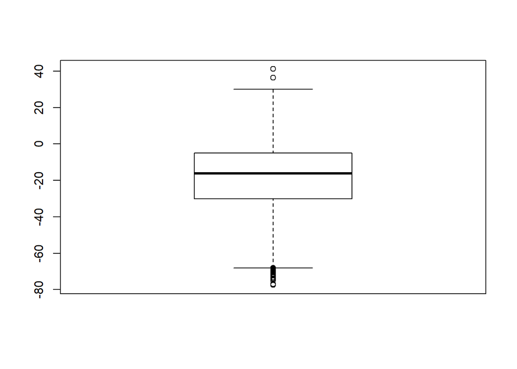

```r
boxplot(bmi-cdc$age)
```

It would seem that age and BMI should have a relationship to one another, as with increased age health begins to decline. However, the boxplot is a poor way to display this information. A scatter plot would convey the two dimensional data in a much clearer and conciser way.

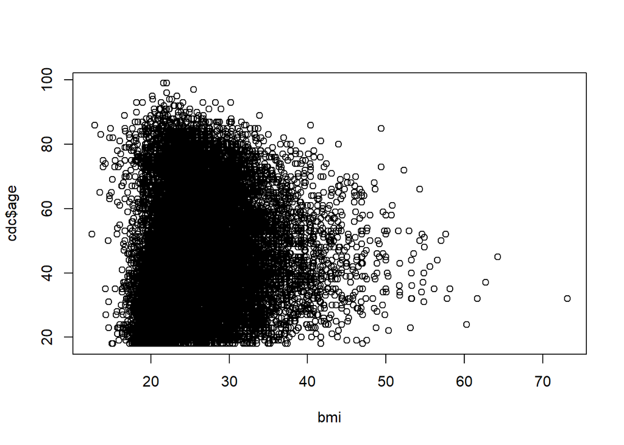

```r
plot(bmi,cdc$age)
```